# Modeling Diel Air Temperature

Hao-Ran Wu ( haoranwu @ zju.edu.cn )

2022-09-24

In this section we are concerned about how to calculate diel air temperature through the function `hourlyT()`.

## Code Example

```r
# Calculate Diel Air Temperature
# ********************************
#
# Calculate diel air temperature based on the algorithm proposed by Parton and
# Logan (1981).
#
# ********************************
# List of variables and units for this example
#
# 'year'        experimental year
# ’month'       experimental month
# 'day'         experimental day
# 'hours'       hours of the day
# 't_max'       daily maximum air temperature (Celsius or Fahrenheit)
# 't_min'       daily minimum air temperature (Celsius or Fahrenheit)
# 'lng'         longitute of the study site (decimal)
# 'lat'         latitude of the study site (decimal)
#
# 'doy'         day of the year
# 'time_sr'     sunrise time (hour)
# 'time_ss'     sunset time (hour)
# 't_a'         air temperature (Celsius or Fahrenheit)
#
# ********************************
# Step 1: import package
require(bproce)

# Step 2: choose parameters
year  <- 2016
month <- 9
day   <- 22
hours <- seq(0, 23.5, 0.5)      # 0.5h, 1h, 1.5h, ..., 23.5h
t_max <- 30.2
t_min <- 14.3
lng   <- -85.446758
lat   <- 42.476708

# Step 3: run the model
doy <- DOY(year, month, day)          # calculate day of the year (DOY)

time_sr <- sunRS(doy, lng, lat)[[1]]  # calculate sunrise time
time_ss <- sunRS(doy, lng, lat)[[2]]  # calculate sunset time

t_a <- hourlyT(hours, t_max, t_min, time_sr, time_ss,
                    alpha = 1.5, beta = 4, gamma = 1)
                                      # compute diel air temperature

# Step 4: show and visualize results
# hours are given in the first column while the corresponding air temperature is shown in the second column
print(data.frame(hours, t_a))

# plot air temperature versus time
plot(
  hours, t_a, type = "l",
  xlab = "Hours",
  ylab = "Predicted air temperature",
  main = "Diel Air Temperature"
)
```

## Explanation

**Step1:** Load the package `bproce` through the `require()` function.

```r
require(bproce)
```

**Step2:** Choose model parameters.

- `day`, `month`, and `year`: Experimental day. The provided example calculates the diel air temperature for 22 September 2016 at 42.476708<sup>o</sup>N and, therefore, we assigns 22 to the variable `day`, 9 to `month`, 2016 to `year`.
- `hours`: Hours of the day used for calculating air temperature. The provided example calculates air temperature in half-hour time resolution. Thus, we assigns time series (0h, 0.5h, 1h, …, 23.5h) to the variable hours through the function `seq`.
- `t_max`: Daily maximum air temperature (Celsius or Fahrenheit). The provided example assigns 30.2°C as the maximum temperature for 22 September, 2016.
- `t_min`: Daily minimum temperature (Celsius or Fahrenheit). The provided example assigns 14.3°C as the minimum temperature for 22 September, 2016.
- `lng`: Longitude of the study site (in decimal). The provided example focuses on the air temperature at 85.446758<sup>o</sup>W.
- `lat`: Latitude of the study site (in decimal). The provided example focuses on the air temperature at 42.476708<sup>o</sup>N.

```r
year  <- 2016
month <- 9
day   <- 22
hours <- seq(0, 23.5, 0.5)
t_max <- 30.2
t_min <- 14.3
lng   <- -85.446758
lat   <- 42.476708
```

**Step3:** Run the model. The first step is to calculate day of the year (DOY) using the following equation:

$$\text{DOY}=\left[ \frac{275\text{month}}{9}
\right]-\left[\frac{\text{month}+9}{12}\right]·
\left(\left[ \frac{\text{year}-4\text[\text{year}/4]+2}{3}
\right]+1\right)+\text{day}-30,\quad(1)$$

```r
doy <- DOY(year, month, day)
cat(paste0(day,"/",month,"/",year," is the ",doy,"th day of ",year,".\n"))
```

```
22/9/2016 is the 266th day of 2016.
```

Sunrise time (Time<sub>sr</sub>, hour) and sunset time (Time<sub>ss</sub>, hour) are then calculated through the function `sunRS()` (see Section 1.4 for theoretical formulations):

```r
time_sr <- sunRS(doy, lng, lat)[[1]]
time_ss <- sunRS(doy, lng, lat)[[2]]

cat(
  paste0("Longitude = ",lng, ", Latitude = ",lat,".\n"),
  paste0("The sunrise time on ",day,"/",month,"/",year," is ",
         floor(time_sr),":",round((time_sr-floor(time_sr))*60),".\n"),
  paste0("The sunset time on ",day,"/",month,"/",year," is ",
         floor(time_ss),":",round((time_ss-floor(time_ss))*60),".\n"),
  "Day length =",round(time_ss-time_sr,2),"(hour).\n"
)
```

```
Longitude = -85.446758, Latitude = 42.476708.
 The sunrise time on 22/9/2016 is 5:48.
 The sunset time on 22/9/2016 is 17:56.
 Day length = 12.13 (hour).
```

A model proposed by Parton and Logan (1981) is then used to calculate air temperature. Air temperature $T_a$ between sunrise (plus an time lag $\gamma$ for $T_{min}$) and sunset is calculated as:

$$T_{sr}=(T_{max}-T_{min})·\sin\left(
\frac{\pi·(D_L-\gamma)}{D_L+2\alpha}\right)+T_{min},\quad(4)$$

where $\gamma$ is the time lag for $T_{min}$. All these work can be done after the function `hourlyT()` is called:

```r
t_a <- hourlyT(hours, t_max, t_min, time_sr, time_ss,
                    alpha = 1.5, beta = 4, gamma = 1)
```

The arguments and their meaning of `hourlyT()` is shown in the table below:

| Argument | Data Type | Meaning | Symbol |
| --- | --- | --- | --- |
| `hours` | vector | time in hours used for calculating air temperature | / |
| `t_max` | scalar | maximum air temperature (Celsius or Fahrenheit) | $T_{max}$ |
| `t_min` | scalar | minimum air temperature (Celsius or Fahrenheit) | $T_{min}$ |
| `time_sr` | scalar | sunrise time (hour) | $\text{Time}_{\text{sr}}$ |
| `time_ss` | scalar | sunset time (hour) | $\text{Time}_{\text{ss}}$ |
| `alpha` | scalar | lag time for $T_{max}$ (hour). Default 1.5. | $\alpha$ |
| `beta` | scalar | nighttime temperature coefficient. Default 4. | $\beta$ |
| `gamma` | scalar | lag time for $T_{min}$ (hour). Default 1. | $\gamma$ |

The returned vector `t_a` has the same length as `hours`, each entry corresponding to the predicted air temperature at a given time step.

**Step4:** Show and visualize results. Use the function `data.frame()` function to create a data frame, tightly coupled vector `hours` and `t_a`. Then print the data frame:

```r
res <- data.frame(hours, t_a)

cat(
  paste0("Date = ",day,"/",month,"/",year,"\n"),
  "Longitude =",lng,"\n",
  "Latitude =",lat,"\n",
  paste0("Sunrise and sunset time = (",round(time_sr,2),
         ", ",round(time_ss,2),") (hour)\n"),
  "Predicted air temperature:\n"
)
```

```
Date = 22/9/2016
 Longitude = -85.44676
 Latitude = 42.47671
 Sunrise and sunset time = (5.8, 17.93) (hour)
 Predicted air temperature:
```

```r
print(res, digits=4)
```

```
   hours   t_a
1    0.0 15.82
2    0.5 15.58
3    1.0 15.38
4    1.5 15.22
5    2.0 15.07
6    2.5 14.95
7    3.0 14.85
8    3.5 14.77
9    4.0 14.69
10   4.5 14.63
11   5.0 14.58
12   5.5 14.54
13   6.0 14.50
14   6.5 14.47
```

[output cut: 34 more lines]

Create a line plot of predicted air temperature against time through the function `plot()`:

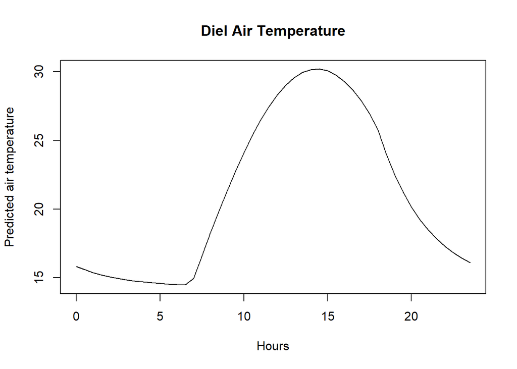

```r
plot(
  hours, t_a, type = "l",
  xlab = "Hours",
  ylab = "Predicted air temperature",
  main = "Diel Air Temperature"
)
```

## References

Parton, W. J., and Logan, J. A. (1981). A model for diurnal variation in soil and air temperature. Agricultural Meteorology, 23, 205–216.